# chapter 9 question 6

Mukul Goyal

October 22, 2019

## Question 6

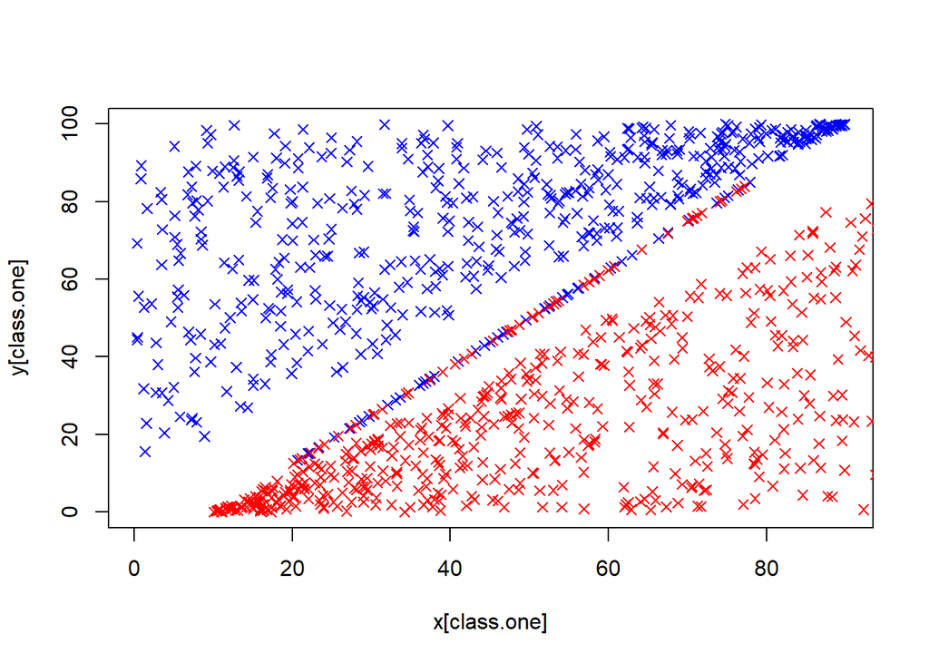

```r
set.seed(1010)

#Class one
x.one = runif(500,0,90)
y.one = runif(500,x.one+10,100)
x.one.noise = runif(50,20,80)
y.one.noise = 5/4 * (x.one.noise - 10) +0.1

#Class zero
x.zero = runif(500,10,100)
y.zero = runif(500,0,x.zero-10)
x.zero.noise = runif(50,20,80)
y.zero.noise = 5/4 * (x.zero.noise - 10) - 0.1

#Combine data of both class
class.one = seq(1,550)
x = c(x.one,x.one.noise, x.zero, x.zero.noise)
y = c(y.one, y.one.noise, y.zero, y.zero.noise)


plot(x[class.one], y[class.one], col="blue", pch=4, ylim=c(0,100))
points(x[-class.one], y[-class.one], col="red", pch=4)
```

Now we calculate the cross-validation errors for range of cost values.

```r
z = rep(0,1100)
z[class.one] = 1
data.xy = data.frame(x=x, y=y, z=z)
```

```r
library(e1071)
tune.out = tune(svm, as.factor(z)~., data= data.xy, kernel= "linear" ,ranges = list(cost=c(0.01,0.1,1,5,10,100,1000)))
summary(tune.out)
```

```
##
## Parameter tuning of 'svm':
##
## - sampling method: 10-fold cross validation
##
## - best parameters:
##  cost
##  1000
##
## - best performance: 0.01272727
##
## - Detailed performance results:
##    cost      error dispersion
## 1 1e-02 0.05636364 0.02634796
## 2 1e-01 0.04636364 0.02161947
## 3 1e+00 0.04818182 0.02187283
## 4 5e+00 0.05090909 0.02275756
## 5 1e+01 0.05000000 0.02237094
## 6 1e+02 0.04727273 0.02339425
## 7 1e+03 0.01272727 0.01368678
```

Model with `cost=1000` gives out lowest error rate. Now, we can make a table of mis-classification rate associated with each cost.

```r
data.frame(tune.out$performances[1], tune.out$performances[2]*1100)
```

```
##    cost error
## 1 1e-02    62
## 2 1e-01    51
## 3 1e+00    53
## 4 5e+00    56
## 5 1e+01    55
## 6 1e+02    52
## 7 1e+03    14
```

Small value of cost = misclassify a couple of training observation = Wider margin

High value of cost = does not misclassify training observation = narrow margin

model with high cost(i.e. `cost =1000`) misclassifies lowest training observation.

We will now generate a test set.

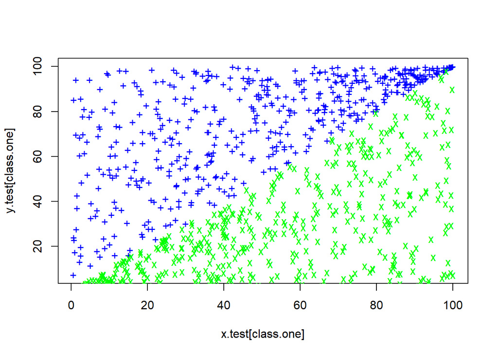

```r
set.seed(10)

x.test = runif(1000,0,100)
class.one = sample(1000,500)
y.test = rep(NA,1000)

#Set y > x for class.one
for(i in class.one){
  y.test[i] = runif(1, x.test[i],100)
}
for (i in setdiff(1:1000, class.one)){
  y.test[i] = runif(1,0,
                    x.test[i])
}
plot(x.test[class.one], y.test[class.one], col="blue", pch="+")
points(x.test[-class.one], y.test[-class.one], col="green", pch="x")
```

This test set satisfies the true decision boundary x=y.

We will now make prediction on test set using models of different cost.

```r
z.test = rep(0,1000)
z.test[class.one] = 1
all.costs  = c(0.01,0.1,1,5,10,100,1000)
test.errors = rep(NA, length(all.costs))
data.test = data.frame(x = x.test, y= y.test, z= z.test)
for(i in 1:length(all.costs)){
  svm.fit = svm(as.factor(z)~., data= data.xy, kernel="linear", cost= all.costs[i])
  svm.pred = predict(svm.fit, data.test)
  test.errors[i] = sum(svm.pred != data.test$z)

}
data.frame(cost = all.costs, "testmisclass"= test.errors)
```

```
##    cost testmisclass
## 1 1e-02           53
## 2 1e-01           15
## 3 1e+00            3
## 4 5e+00            0
## 5 1e+01            0
## 6 1e+02          181
## 7 1e+03          198
```

Model with `cost=5` performs well on test data set rather than model with `cost=1000` as seen previously. Thus model with lower cost performs well on test data set.

## Question No.7

```r
library(ISLR)
library(e1071)
```

**(a)** Creating a binary variable taking 1 for cars with gas mileage above median and 0 for cars with gas mileage below median.

```r
Auto$mileage = ifelse(Auto$mpg > median(Auto$mpg),1,0)
attach(Auto)
```

**(b)**

```r
set.seed(100)
tune.out = tune(svm,as.factor(mileage)~.-mpg, kernel= "linear" ,data= Auto, ranges = list(cost=c(0.01,0.1,1,5,10,100,1000)))
summary(tune.out)
```

```
##
## Parameter tuning of 'svm':
##
## - sampling method: 10-fold cross validation
##
## - best parameters:
##  cost
##  0.01
##
## - best performance: 0.08929487
##
## - Detailed performance results:
##    cost      error dispersion
## 1 1e-02 0.08929487 0.04382379
## 2 1e-01 0.09442308 0.04354788
## 3 1e+00 0.09185897 0.02451228
## 4 5e+00 0.10211538 0.02956457
## 5 1e+01 0.09955128 0.03291438
## 6 1e+02 0.13532051 0.05686046
## 7 1e+03 0.10980769 0.04694639
```

Lowest CV- error is with a cost of 0.01.

**(c)** Trying polynomial kernel with degrees= 1,2,3,4,5

```r
set.seed(99)
tune.out = tune(svm, as.factor(mileage)~.-mpg, kernel = "polynomial", data= Auto, ranges = list(cost=c(0.01,0.1,1,5,10,100,1000), degree = c(1,2,3,4,5)))
summary(tune.out)
```

```
##
## Parameter tuning of 'svm':
##
## - sampling method: 10-fold cross validation
##
## - best parameters:
##  cost degree
##   100      1
##
## - best performance: 0.07923077
##
## - Detailed performance results:
##     cost degree      error dispersion
## 1  1e-02      1 0.53314103 0.03203425
## 2  1e-01      1 0.19403846 0.11567155
```

[output cut: 33 more lines]

Lowest CV- error is with `cost=100` and `degree=1`.

**(d)**

Now, trying radial kernel:

```r
set.seed(1010)
tune.out = tune(svm, as.factor(mileage)~.-mpg, kernel = "radial", data= Auto, ranges =  list(cost=c(0.01,0.1,1,5,10), gamma = c(0.01,0.1,1,5,10)))
summary(tune.out)
```

```
##
## Parameter tuning of 'svm':
##
## - sampling method: 10-fold cross validation
##
## - best parameters:
##  cost gamma
##    10   0.1
##
## - best performance: 0.07916667
##
## - Detailed performance results:
##     cost gamma      error dispersion
## 1   0.01  0.01 0.48608974 0.14877015
## 2   0.10  0.01 0.11467949 0.04816606
## 3   1.00  0.01 0.08929487 0.03655289
## 4   5.00  0.01 0.09692308 0.03569054
## 5  10.00  0.01 0.08416667 0.03805105
## 6   0.01  0.10 0.18141026 0.07733803
## 7   0.10  0.10 0.09185897 0.03843785
## 8   1.00  0.10 0.09185897 0.03648788
## 9   5.00  0.10 0.08166667 0.04296859
## 10 10.00  0.10 0.07916667 0.04394780
## 11  0.01  1.00 0.45858974 0.20672173
## 12  0.10  1.00 0.45858974 0.20672173
## 13  1.00  1.00 0.08166667 0.04624398
## 14  5.00  1.00 0.08673077 0.04995071
## 15 10.00  1.00 0.08673077 0.04995071
## 16  0.01  5.00 0.53858974 0.05067464
## 17  0.10  5.00 0.53858974 0.05067464
## 18  1.00  5.00 0.48730769 0.05081860
## 19  5.00  5.00 0.48730769 0.05081860
## 20 10.00  5.00 0.48730769 0.05081860
## 21  0.01 10.00 0.52858974 0.06547198
## 22  0.10 10.00 0.52858974 0.06547198
## 23  1.00 10.00 0.48269231 0.07180505
## 24  5.00 10.00 0.49275641 0.05731441
## 25 10.00 10.00 0.49275641 0.05731441
```

Lowest CV- error is with `cost=10` and `gamma= 0.1`.

**(d)**

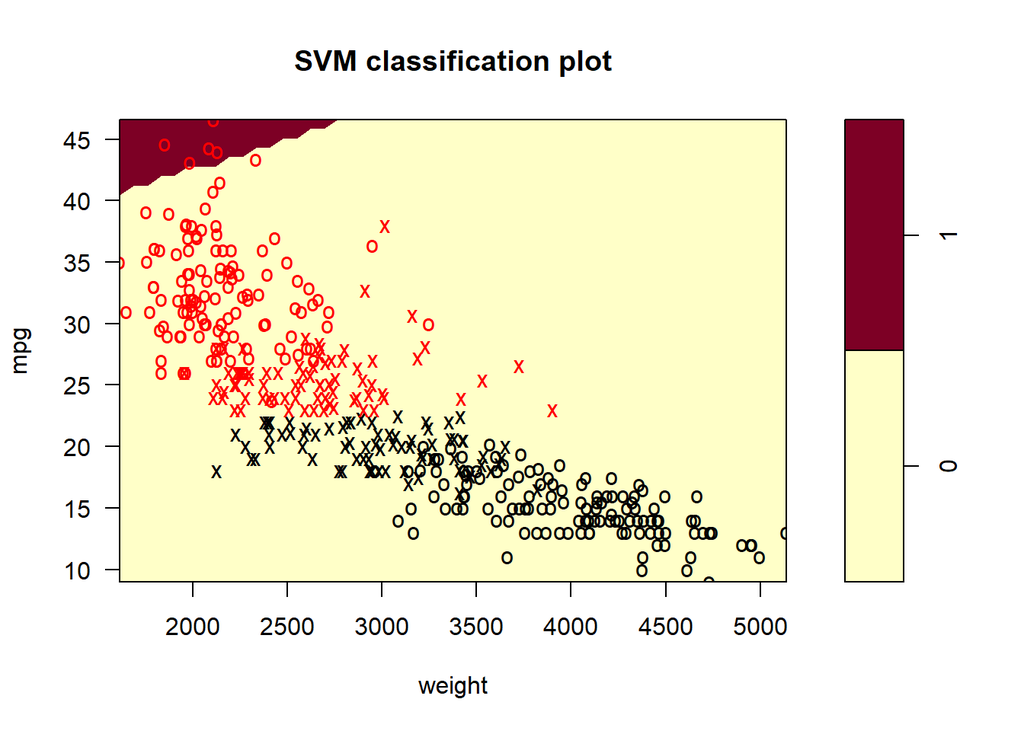

```r
svm.linear = svm(as.factor(mileage)~., data= Auto, kernel = "linear", cost= 0.01)
plot(svm.linear, Auto, mpg~weight)
```

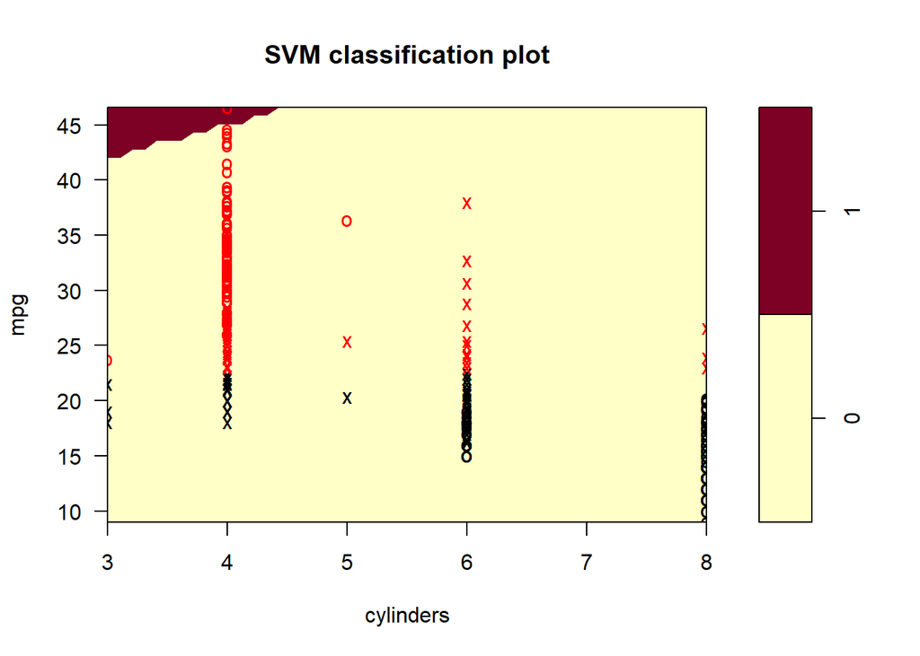

```r
plot(svm.linear, Auto, mpg~cylinders)
```

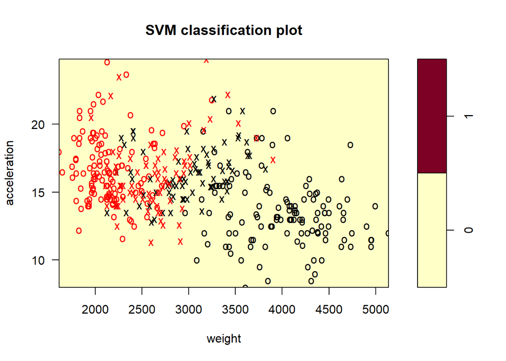

```r
plot(svm.linear, Auto, acceleration~weight)
```